# Classifier

## Load Data

The original dataset contains 19622 observations and 160 variables. **The last variable is the outcome and is called classe**

```
##        X            user_name    raw_timestamp_part_1 raw_timestamp_part_2
##  Min.   :    1   adelmo  :3892   Min.   :1.322e+09    Min.   :   294
##  1st Qu.: 4906   carlitos:3112   1st Qu.:1.323e+09    1st Qu.:252912
##  Median : 9812   charles :3536   Median :1.323e+09    Median :496380
##  Mean   : 9812   eurico  :3070   Mean   :1.323e+09    Mean   :500656
##  3rd Qu.:14717   jeremy  :3402   3rd Qu.:1.323e+09    3rd Qu.:751891
##  Max.   :19622   pedro   :2610   Max.   :1.323e+09    Max.   :998801
##
##           cvtd_timestamp  new_window    num_window      roll_belt
##  28/11/2011 14:14: 1498   no :19216   Min.   :  1.0   Min.   :-28.90
##  05/12/2011 11:24: 1497   yes:  406   1st Qu.:222.0   1st Qu.:  1.10
##  30/11/2011 17:11: 1440               Median :424.0   Median :113.00
##  05/12/2011 11:25: 1425               Mean   :430.6   Mean   : 64.41
##  02/12/2011 14:57: 1380               3rd Qu.:644.0   3rd Qu.:123.00
##  02/12/2011 13:34: 1375               Max.   :864.0   Max.   :162.00
##  (Other)         :11007
##    pitch_belt          yaw_belt       total_accel_belt kurtosis_roll_belt
##  Min.   :-55.8000   Min.   :-180.00   Min.   : 0.00             :19216
##  1st Qu.:  1.7600   1st Qu.: -88.30   1st Qu.: 3.00    #DIV/0!  :   10
##  Median :  5.2800   Median : -13.00   Median :17.00    -1.908453:    2
##  Mean   :  0.3053   Mean   : -11.21   Mean   :11.31    -0.016850:    1
##  3rd Qu.: 14.9000   3rd Qu.:  12.90   3rd Qu.:18.00    -0.021024:    1
##  Max.   : 60.3000   Max.   : 179.00   Max.   :29.00    -0.025513:    1
##                                                        (Other)  :  391
##  kurtosis_picth_belt kurtosis_yaw_belt skewness_roll_belt
##           :19216            :19216              :19216
##  #DIV/0!  :   32     #DIV/0!:  406     #DIV/0!  :    9
##  47.000000:    4                       0.000000 :    4
##  -0.150950:    3                       0.422463 :    2
##  -0.684748:    3                       -0.003095:    1
##  -1.750749:    3                       -0.010002:    1
##  (Other)  :  361                       (Other)  :  389
##  skewness_roll_belt.1 skewness_yaw_belt max_roll_belt     max_picth_belt
##           :19216             :19216     Min.   :-94.300   Min.   : 3.00
##  #DIV/0!  :   32      #DIV/0!:  406     1st Qu.:-88.000   1st Qu.: 5.00
##  0.000000 :    4                        Median : -5.100   Median :18.00
##  -2.156553:    3                        Mean   : -6.667   Mean   :12.92
##  -3.072669:    3                        3rd Qu.: 18.500   3rd Qu.:19.00
##  -6.324555:    3                        Max.   :180.000   Max.   :30.00
##  (Other)  :  361                        NA's   :19216     NA's   :19216
```

[output cut: 313 more lines]

```
##  Min.   :-446.00   Min.   :-1280.0   Min.   :-896.0   Min.   :-973.0
##  1st Qu.:-182.00   1st Qu.: -616.0   1st Qu.:   2.0   1st Qu.: 191.0
##  Median : -39.00   Median : -378.0   Median : 591.0   Median : 511.0
##  Mean   : -55.29   Mean   : -312.6   Mean   : 380.1   Mean   : 393.6
##  3rd Qu.:  26.00   3rd Qu.:  -73.0   3rd Qu.: 737.0   3rd Qu.: 653.0
##  Max.   : 291.00   Max.   :  672.0   Max.   :1480.0   Max.   :1090.0
##
##  classe
##  A:5580
##  B:3797
##  C:3422
##  D:3216
##  E:3607
##
##
```

As you can see in the summary many of the variables have a great amount of NAs

## Cleaning data

We use the nearZerovar package to remove variables with little variability from the model. Then we use the cor function to discover correlated variables keeping only one representative for groups of similar behavior groups. For example, looking the next table showing the correlated variables we can see the variable 2 (roll_belt) is very correlated (above 0.8) with variables 4 (yaw_belt), 5 (total_accel_belt), 10 (accel_belt_y) and 11 (accel_belt_z), so we can remove these variables from the dataset and only keep the variable 2.

|  | row | col |
| --- | --- | --- |
| yaw_belt | 4 | 2 |
| total_accel_belt | 5 | 2 |
| accel_belt_y | 10 | 2 |
| accel_belt_z | 11 | 2 |
| accel_belt_x | 9 | 3 |
| magnet_belt_x | 12 | 3 |
| roll_belt | 2 | 4 |
| roll_belt | 2 | 5 |
| accel_belt_y | 10 | 5 |
| accel_belt_z | 11 | 5 |
| pitch_belt | 3 | 9 |
| magnet_belt_x | 12 | 9 |
| roll_belt | 2 | 10 |
| total_accel_belt | 5 | 10 |
| accel_belt_z | 11 | 10 |
| roll_belt | 2 | 11 |
| total_accel_belt | 5 | 11 |
| accel_belt_y | 10 | 11 |
| pitch_belt | 3 | 12 |
| accel_belt_x | 9 | 12 |
| gyros_arm_y | 20 | 19 |
| gyros_arm_x | 19 | 20 |
| magnet_arm_x | 25 | 22 |
| accel_arm_x | 22 | 25 |
| magnet_arm_z | 27 | 26 |
| magnet_arm_y | 26 | 27 |
| accel_dumbbell_x | 35 | 29 |
| accel_dumbbell_z | 37 | 30 |
| gyros_dumbbell_z | 34 | 32 |
| gyros_forearm_z | 47 | 32 |
| gyros_dumbbell_x | 32 | 34 |
| gyros_forearm_z | 47 | 34 |
| pitch_dumbbell | 29 | 35 |
| yaw_dumbbell | 30 | 37 |
| gyros_forearm_z | 47 | 46 |
| gyros_dumbbell_x | 32 | 47 |
| gyros_dumbbell_z | 34 | 47 |
| gyros_forearm_y | 46 | 47 |

After all cleaning processes we get a reduce dataset of 41 variables including the outcome one (classe)

## Split data

We take a random partition of 70% from the dataset for training purpose and the 30% for cross validation.

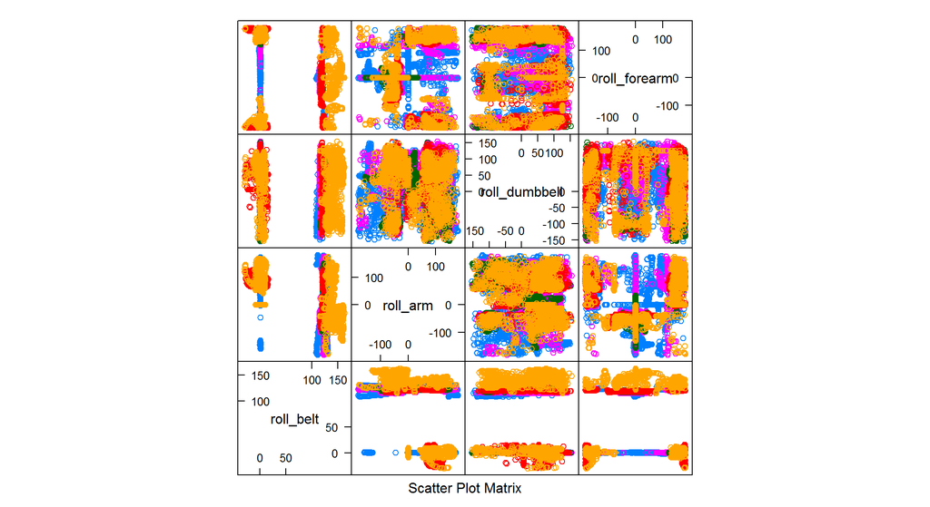

As can be sawn in the figure there are few colored groups (colour represent the outcome variable) with a clear pattern, so the classifier won’t probably be very accurate

## Classifier

I have tested with several algorithms for multiclass classifier (Random Forest, glmet, Naibe Bayes) but my laptop haven’t achieved ending the model train after quite time. Hovewer, it got finish using the lda (Linear Discriminant Analysis) model in little time with a global accuracy about 64%

```
## Confusion Matrix and Statistics
##
##           Reference
## Prediction    A    B    C    D    E
##          A 1210  256   91   33   52
##          B  167  576   68   81  165
##          C  162  167  673  128   98
##          D  110   57  148  673  102
##          E   25   83   46   49  665
##
## Overall Statistics
##
##                Accuracy : 0.6452
##                  95% CI : (0.6328, 0.6574)
##     No Information Rate : 0.2845
##     P-Value [Acc > NIR] : < 2.2e-16
##
##                   Kappa : 0.552
##  Mcnemar's Test P-Value : < 2.2e-16
##
## Statistics by Class:
##
##                      Class: A Class: B Class: C Class: D Class: E
## Sensitivity            0.7228  0.50571   0.6559   0.6981   0.6146
## Specificity            0.8974  0.89865   0.8858   0.9153   0.9577
## Pos Pred Value         0.7369  0.54494   0.5480   0.6174   0.7661
## Neg Pred Value         0.8906  0.88339   0.9242   0.9393   0.9169
## Prevalence             0.2845  0.19354   0.1743   0.1638   0.1839
## Detection Rate         0.2056  0.09788   0.1144   0.1144   0.1130
## Detection Prevalence   0.2790  0.17961   0.2087   0.1852   0.1475
## Balanced Accuracy      0.8101  0.70218   0.7709   0.8067   0.7862
```

The confusion matrix show the most relevant information about the classifier and the stimated accuracy for each class

## Basic Preprocess and PCA

I have done another tests with simple preprocessing and PCA, but the results haven´t improved the results got with the original model. Ex. with 20 PCs the global accuracy is 10 points (%) below the original model

```r
#modelFitPrep <- train(classe ~.,data=training, preProcess=c("center","scale"),method="lda")

preProc <- preProcess(training[,-41],method="pca",pcaComp=20)
trainPC <- predict(preProc,training[,-41])
modelFitPC <- train(training$classe ~.,data=trainPC, method="lda")
testPC <- predict(preProc,testing[,-41])

predictions <- predict(modelFitPC,newdata=testPC)
confusionMatrix(predictions, testing$classe)
```

```
## Confusion Matrix and Statistics
##
##           Reference
## Prediction    A    B    C    D    E
##          A 1099  192  303   80  165
##          B  135  547  112  188  146
##          C  174  200  481  144  117
##          D  220  160   75  454  135
##          E   46   40   55   98  519
##
## Overall Statistics
##
##                Accuracy : 0.5268
##                  95% CI : (0.5139, 0.5396)
##     No Information Rate : 0.2845
##     P-Value [Acc > NIR] : < 2.2e-16
##
##                   Kappa : 0.3996
##  Mcnemar's Test P-Value : < 2.2e-16
##
## Statistics by Class:
##
##                      Class: A Class: B Class: C Class: D Class: E
## Sensitivity            0.6565  0.48025  0.46881  0.47095  0.47967
## Specificity            0.8243  0.87758  0.86931  0.88011  0.95024
## Pos Pred Value         0.5976  0.48493  0.43100  0.43487  0.68470
## Neg Pred Value         0.8579  0.87555  0.88572  0.89465  0.89019
## Prevalence             0.2845  0.19354  0.17434  0.16381  0.18386
## Detection Rate         0.1867  0.09295  0.08173  0.07715  0.08819
## Detection Prevalence   0.3125  0.19167  0.18963  0.17740  0.12880
## Balanced Accuracy      0.7404  0.67891  0.66906  0.67553  0.71495
```